# Portfolio optimization under natural clustering

## Stock portfolio via sector clustering

This R script is accompanying Section 9.2 (Stock portfolio application) of “Portfolio optimization under natural clustering” by Debrauwer and Gijbels.

In this script we implement the two step optimizations. Useful packages are the following.

```r
library(quantmod)
library(copula)
library(stats)
library(tictoc)
library(parallel)
library(foreach)
library(doParallel)
library(latex2exp)
```

Load stock data from Yahoo finance for the period 2024-01-01 until 2025-01-01.

```r
start_date <- "2024-01-01"
end_date <- "2025-01-01"
```

Technology sector

```r
#Apple
apple_df <- getSymbols('AAPL', src='yahoo', auto.assign=FALSE)
apple <- exp(as.numeric(diff(log(apple_df$AAPL.Close[start_date <= index(apple_df) & index(apple_df) < end_date])))[-1])

#Microsoft
microsoft_df <- getSymbols('MSFT', src='yahoo', auto.assign=FALSE)
microsoft <- exp(as.numeric(diff(log(microsoft_df$MSFT.Close[start_date <= index(microsoft_df) & index(microsoft_df) < end_date])))[-1])

#Google
google_df <- getSymbols('GOOGL', src='yahoo', auto.assign=FALSE)
google <- exp(as.numeric(diff(log(google_df$GOOGL.Close[start_date <= index(google_df) & index(google_df) < end_date])))[-1])

#Adobe
adobe_df <- getSymbols('ADBE', src='yahoo', auto.assign=FALSE)
adobe <- exp(as.numeric(diff(log(adobe_df$ADBE.Close[start_date <= index(adobe_df) & index(adobe_df) < end_date])))[-1])
```

Healthcare sector

```r
#Johnson & Johnson
johnson_df <- getSymbols('JNJ', src='yahoo', auto.assign=FALSE)
johnson <- exp(as.numeric(diff(log(johnson_df$JNJ.Close[start_date <= index(johnson_df) & index(johnson_df) < end_date])))[-1])

#Pfizer
pfizer_df <- getSymbols('PFE', src='yahoo', auto.assign=FALSE)
pfizer <- exp(as.numeric(diff(log(pfizer_df$PFE.Close[start_date <= index(pfizer_df) & index(pfizer_df) < end_date])))[-1])

#Merck
merck_df <- getSymbols('MRK', src='yahoo', auto.assign=FALSE)
merck <- exp(as.numeric(diff(log(merck_df$MRK.Close[start_date <= index(merck_df) & index(merck_df) < end_date])))[-1])

#abbvie
abbvie_df <- getSymbols('ABBV', src='yahoo', auto.assign=FALSE)
abbvie <- exp(as.numeric(diff(log(abbvie_df$ABBV.Close[start_date <= index(abbvie_df) & index(abbvie_df) < end_date])))[-1])
```

Finance sector

```r
#JPMorgan Chase
jpmorgan_df <- getSymbols('JPM', src='yahoo', auto.assign=FALSE)
jpmorgan<- exp(as.numeric(diff(log(jpmorgan_df$JPM.Close[start_date <= index(jpmorgan_df) & index(jpmorgan_df) < end_date])))[-1])

#Goldman Sachs
goldman_df <- getSymbols('GS', src='yahoo', auto.assign=FALSE)
goldman <- exp(as.numeric(diff(log(goldman_df$GS.Close[start_date <= index(goldman_df) & index(goldman_df) < end_date])))[-1])

#Bank of America
bank_df <- getSymbols('BAC', src='yahoo', auto.assign=FALSE)
bank <- exp(as.numeric(diff(log(bank_df$BAC.Close[start_date <= index(bank_df) & index(bank_df) < end_date])))[-1])

#Morgan Stanley
stanley_df <- getSymbols('MS', src='yahoo', auto.assign=FALSE)
stanley <- exp(as.numeric(diff(log(stanley_df$MS.Close[start_date <= index(stanley_df) & index(stanley_df) < end_date])))[-1])
```

To work with $\widetilde{R}_t$ as explained in the paper, we define:

```r
df=data.frame(apple,microsoft,google,adobe,johnson,pfizer,merck,abbvie,jpmorgan,goldman,bank,stanley)
df=df-1
```

The following function implements the full nonparametric estimator (NP) from Debrauwer and Gijbels (2024) in the case of Extremiles. Here tau = risk level (0.95 here), and the data should be the portfolio weighted returns. The output is the estimated extremile risk. We also define a helper function called “risk”, this function only requires portfolio weights. This latter function then calls ExtrNPNP using tau=0.95 and our dataset of stocks weighted by the given inputvector $x$.

```r
ExtrNPNP=function(tau,data){
  library(copula)
  set.seed(1)
  X=data
  u=pobs(X)
  ecop.orig  <- empCopula(u,smoothing="beta")   #Empirical Beta copula
  U.orig  <-  rCopula(100000, copula = ecop.orig)
  GiantSampleMatrix=toEmpMargins(U.orig,x=X)
  Zcol=rowSums(GiantSampleMatrix)
  FecdfEvaluated=rank(Zcol)/(length(Zcol)+1)
  d_tau=function(x,tau){((log(0.5)/log(1-tau)*(1-x)^(log(0.5)/log(1-tau)-1))*as.numeric(tau>0)*as.numeric(tau<=0.5)+log(0.5)/log(tau)*x^(log(0.5)/log(tau)-1)*as.numeric(tau>0.5)*as.numeric(tau<=1))*as.numeric(x<1)}
  partialLoss=function(z,t){-2*(z-t)}
  lambda=function(t,tau){
    FecdfEvaluated[which(FecdfEvaluated==1)]=0
    DFZ=matrix(d_tau(FecdfEvaluated,tau),nrow=1)
    return(1/length(DFZ)*DFZ%*%matrix(partialLoss(Zcol,t),ncol=1))}
  findroot=function(tau){
    return(uniroot(function(t){lambda(t,tau)},lower=min(Zcol),upper=max(Zcol),extendInt = "yes")$root)
  }

  EstimatedExtr=findroot(tau)
  return(EstimatedExtr)

}


risk=function(x){
  return(ExtrNPNP(0.95,data=as.matrix(-df)%*%diag(x)))}
```

We implement every Optimization (1–5) separately. Starting with Optimization 1

## Optimization 1

```r
###### Generate weights for within cluster optimization
generate_combinations <- function(current, remaining, max_sum) {
  if (length(remaining) == 0) {
    last_value <- max_sum - sum(current)
    if (last_value > 0) {
      return(list(c(current, last_value)))
    } else {
      return(list())
    }
  }

  result <- list()
  w <- seq(0.01, 0.99, 0.01)
  for (value in w) {
    new_sum <- sum(current) + value
    if (new_sum < max_sum) {
      new_current <- c(current, value)
      result <- c(result, generate_combinations(new_current, remaining[-1], max_sum))
    }
  }

  return(result)
}

# Generate combinations
combinations <- generate_combinations(numeric(0), rep(1, 3), 1)
combinations <- do.call(rbind, combinations)
combinations <- as.matrix(combinations)
Grid=combinations


##Per cluster we determine the optimal weights (stage 1 of Optimization 1)


############################### cluster 1
risk=function(x){
  return(ExtrNPNP(0.95,data=as.matrix(-df[,1:4])%*%diag(x)))}

tic()
nCores=parallel::detectCores()-2
cl <- parallel::makeCluster(nCores)
doParallel::registerDoParallel(cl)
NPNPrisk=foreach(i=1:dim(Grid)[1], .combine='c',.export=ls(envir=globalenv())) %dopar% risk(Grid[i,])
parallel::stopCluster(cl)
toc()
cluster1=Grid[which.min(NPNPrisk),]
cluster1#0.55 0.40 0.02 0.03
min(NPNPrisk)#0.02026971




############################### cluster 2
risk=function(x){
  return(ExtrNPNP(0.95,data=as.matrix(-df[,5:8])%*%diag(x)))}

tic()
nCores=parallel::detectCores()-2
cl <- parallel::makeCluster(nCores)
doParallel::registerDoParallel(cl)
NPNPrisk=foreach(i=1:dim(Grid)[1], .combine='c',.export=ls(envir=globalenv())) %dopar% risk(Grid[i,])
parallel::stopCluster(cl)
toc()
cluster2=Grid[which.min(NPNPrisk),]
#cluster 2=0.59 0.15 0.21 0.05
cluster2
min(NPNPrisk)#0.0142816



############################### cluster 3
risk=function(x){
  return(ExtrNPNP(0.95,data=as.matrix(-df[,9:12])%*%diag(x)))}

tic()
nCores=parallel::detectCores()-2
cl <- parallel::makeCluster(nCores)
doParallel::registerDoParallel(cl)
NPNPrisk=foreach(i=1:dim(Grid)[1], .combine='c',.export=ls(envir=globalenv())) %dopar% risk(Grid[i,])
parallel::stopCluster(cl)
toc()
cluster3=Grid[which.min(NPNPrisk),]
cluster3# 0.18 0.11 0.56 0.15
min(NPNPrisk)#0.02048599




### Generate grid of weights for across cluster optimization
###### Generate weigths
generate_combinations <- function(current, remaining, max_sum) {
  if (length(remaining) == 0) {
    last_value <- max_sum - sum(current)
    if (last_value > 0) {
      return(list(c(current, last_value)))
    } else {
      return(list())
    }
  }

  result <- list()
  w <- seq(0.01, 0.99, 0.01)
  for (value in w) {
    new_sum <- sum(current) + value
    if (new_sum < max_sum) {
      new_current <- c(current, value)
      result <- c(result, generate_combinations(new_current, remaining[-1], max_sum))
    }
  }

  return(result)
}

# Generate combinations
combinations <- generate_combinations(numeric(0), rep(1, 2), 1)
combinations <- do.call(rbind, combinations)
combinations <- as.matrix(combinations)
Grid=combinations



##Across cluster optimization (stage 2 of Optimization 1)

variable1=rowSums(t(cluster1*t(df[,1:4])))
variable2=rowSums(t(cluster2*t(df[,5:8])))
variable3=rowSums(t(cluster3*t(df[,9:12])))

risk=function(x){
  return(ExtrNPNP(0.95,data=cbind(-variable1,-variable2,-variable3)%*%diag(x)))}

tic()
nCores=parallel::detectCores()-2
cl <- parallel::makeCluster(nCores)
doParallel::registerDoParallel(cl)
NPNPrisk=foreach(i=1:dim(Grid)[1], .combine='c',.export=ls(envir=globalenv())) %dopar% risk(Grid[i,])
parallel::stopCluster(cl)
toc()
Opt1Between=Grid[which.min(NPNPrisk),]#0.28 0.60 0.12
ExtrOpt1=min(NPNPrisk)#0.01192556
Opt1Between
ExtrOpt1

#Final weight:
#c(0.28*c(0.55,0.40,0.02,0.03), 0.60*c(0.59,0.15,0.21,0.05) ,0.12*c(0.18, 0.11, 0.56, 0.15))

#Risk: 0.01192556
```

## Optimization 2

```r
#Stage 1 of Optimization 2: uniform within cluster weights
variable1=rowSums(t(rep(1/4,4)*t(df[,1:4])))
variable2=rowSums(t(rep(1/4,4)*t(df[,5:8])))
variable3=rowSums(t(rep(1/4,4)*t(df[,9:12])))


##Determine across cluster weights
risk=function(x){
  return(ExtrNPNP(0.95,data=cbind(-variable1,-variable2,-variable3)%*%diag(x)))}

tic()
nCores=parallel::detectCores()-2
cl <- parallel::makeCluster(nCores)
doParallel::registerDoParallel(cl)
NPNPrisk=foreach(i=1:dim(Grid)[1], .combine='c',.export=ls(envir=globalenv())) %dopar% risk(Grid[i,])
parallel::stopCluster(cl)
toc()
Opt2Between=Grid[which.min(NPNPrisk),]#0.21 0.59 0.20
ExtrOpt2=min(NPNPrisk)#0.0130436


##Determine final risk, using again the optimized within cluster weights
variable1=rowSums(t(cluster1*t(df[,1:4])))
variable2=rowSums(t(cluster2*t(df[,5:8])))
variable3=rowSums(t(cluster3*t(df[,9:12])))


risk=function(x){
  return(ExtrNPNP(0.95,data=cbind(-variable1,-variable2,-variable3)%*%diag(x)))}
ExtrOpt2FinalRisk=risk(c(Opt2Between))#0.01206293

FinalWeightOpt2=c(cluster1*Opt2Between[1],cluster2*Opt2Between[2],cluster3*Opt2Between[3])
# 0.1155 0.0840 0.0042 0.0063 0.3481 0.0885 0.1239 0.0295 0.0360 0.0220 0.1120 0.0300
```

## Optimization 3

```r
#Estimate the 95% Extremile of the margins
ExtrMargins=function(data){
  tau=0.95
  d_tau <- function(x, tau) {
    (log(0.5) / log(tau) * x^(log(0.5) / log(tau) - 1) * as.numeric(tau > 0.5) * as.numeric(tau <= 1)) * as.numeric(x <= 1)
  }

  partialLoss <- function(z, t) {
    -2 * (z - t)
  }
  cdfEvaluated=rank(data)/(length(data)+1)

  lambda=function(t,tau){
    cdfEvaluated[which(cdfEvaluated==1)]=0
    DFZ=matrix(d_tau(cdfEvaluated,tau),nrow=1)
    return(1/length(DFZ)*DFZ%*%matrix(partialLoss(data,t),ncol=1))}
  findroot=function(tau){
    return(uniroot(function(t){lambda(t,tau)},lower=min(data),upper=max(data),extendInt = "yes")$root)
  }
  EstimatedExtr=findroot(tau)
  return(EstimatedExtr)
}


##Find the representative for each cluster.


#representative cluster 1
toMinimize1=c(ExtrMargins(-df[,1]),ExtrMargins(-df[,2]),ExtrMargins(-df[,3]),ExtrMargins(-df[,4]))
for (i in 1:4){
  sum=0
  for (k in 5:12){
    sum=sum+abs(cor(df[,i],df[,k],method="kendall"))
  }
  toMinimize1[i]=toMinimize1[i]*sum
}
clusterRepresentative1=which.min(toMinimize1)
#1




#representative cluster 2
toMinimize2=c(ExtrMargins(-df[,5]),ExtrMargins(-df[,6]),ExtrMargins(-df[,7]),ExtrMargins(-df[,8]))
for (i in 5:8){
  sum=0
  for (k in c(1:4,9:12)){
    sum=sum+abs(cor(df[,i],df[,k],method="kendall"))
  }
  toMinimize2[i-4]=toMinimize2[i-4]*sum
}
clusterRepresentative2=which.min(toMinimize2)+4
#7




#representative cluster 3
toMinimize3=c(ExtrMargins(-df[,9]),ExtrMargins(-df[,10]),ExtrMargins(-df[,11]),ExtrMargins(-df[,12]))
for (i in 9:12){
  sum=0
  for (k in c(1:8)){
    sum=sum+abs(cor(df[,i],df[,k],method="kendall"))
  }
  toMinimize3[i-8]=toMinimize3[i-8]*sum
}
clusterRepresentative3=which.min(toMinimize3)+8
#11


##Optimized portfolio using the representatives
risk=function(x){
  return(ExtrNPNP(0.95,data=cbind(-df[,clusterRepresentative1],-df[,clusterRepresentative2],-df[,clusterRepresentative3])%*%diag(x)))}

tic()
nCores=parallel::detectCores()-2
cl <- parallel::makeCluster(nCores)
doParallel::registerDoParallel(cl)
NPNPrisk=foreach(i=1:dim(Grid)[1], .combine='c',.export=ls(envir=globalenv())) %dopar% risk(Grid[i,])
parallel::stopCluster(cl)
toc()
weightsOpt3=Grid[which.min(NPNPrisk),]#0.35 0.30 0.35
min(NPNPrisk)#0.0146372
#Total portfolio weight: 0.35  0  0  0  0  0  0.30  0  0  0  0.35  0
```

## Optimization 4

```r
#From the first stage of Optimization 2 we know the optimal across cluster weights and corresponding risk
#when using uniform within cluster weights.
c(0.21*rep(1/4,4),0.59*rep(1/4,4),0.20*rep(1/4,4))
#Final weight: 0.0525 0.0525 0.0525 0.0525 0.1475 0.1475 0.1475 0.1475 0.0500 0.0500 0.0500 0.0500
#with risk 0.0130436
```

## Optimization 5

```r
#From stage 1 of optimization 1 we know the optimal within cluster weights
cluster1=c(0.55,0.40,0.02,0.03)
cluster2=c(0.59,0.15,0.21,0.05)
cluster3=c(0.18,0.11,0.56,0.15)



variable1=rowSums(t(cluster1*t(df[,1:4])))
variable2=rowSums(t(cluster2*t(df[,5:8])))
variable3=rowSums(t(cluster3*t(df[,9:12])))


##determine across cluster weights
risk=function(x){
  return(ExtrNPNP(0.95,data=cbind(-variable1,-variable2,-variable3)%*%diag(x)))}

ExtrOpt5=risk(c(1/3,1/3,1/3))#0.013001

#weight:
round(c(1/3*cluster1 ,1/3*cluster2, 1/3*cluster3),digits=3)
#0.183333333 0.133333333 0.006666667 0.010000000 0.196666667 0.050000000 0.070000000
#0.016666667 0.060000000 0.036666667 0.186666667 0.050000000
```

## Ljung-Box test

```r
Box.test(apple,lag=3,type="Ljung-Box")
```

```
##
##  Box-Ljung test
##
## data:  apple
## X-squared = 3.022, df = 3, p-value = 0.3882
```

```r
Box.test(microsoft,lag=3,type="Ljung-Box")
```

```
##
##  Box-Ljung test
##
## data:  microsoft
## X-squared = 4.9549, df = 3, p-value = 0.1751
```

```r
Box.test(google,lag=3,type="Ljung-Box")
```

```
##
##  Box-Ljung test
##
## data:  google
## X-squared = 4.3396, df = 3, p-value = 0.227
```

```r
Box.test(adobe,lag=3,type="Ljung-Box")
```

```
##
##  Box-Ljung test
##
## data:  adobe
## X-squared = 0.82667, df = 3, p-value = 0.8431
```

```r
Box.test(johnson,lag=3,type="Ljung-Box")
```

```
##
##  Box-Ljung test
##
## data:  johnson
## X-squared = 2.3389, df = 3, p-value = 0.5051
```

```r
Box.test(pfizer,lag=3,type="Ljung-Box")
```

```
##
##  Box-Ljung test
##
## data:  pfizer
## X-squared = 1.5774, df = 3, p-value = 0.6645
```

```r
Box.test(merck,lag=3,type="Ljung-Box")
```

```
##
##  Box-Ljung test
##
## data:  merck
## X-squared = 0.37212, df = 3, p-value = 0.9459
```

```r
Box.test(abbvie,lag=3,type="Ljung-Box")
```

```
##
##  Box-Ljung test
##
## data:  abbvie
## X-squared = 2.4874, df = 3, p-value = 0.4776
```

```r
Box.test(jpmorgan,lag=3,type="Ljung-Box")
```

```
##
##  Box-Ljung test
##
## data:  jpmorgan
## X-squared = 2.7976, df = 3, p-value = 0.4239
```

```r
Box.test(goldman,lag=3,type="Ljung-Box")
```

```
##
##  Box-Ljung test
##
## data:  goldman
## X-squared = 2.92, df = 3, p-value = 0.4041
```

```r
Box.test(bank,lag=3,type="Ljung-Box")
```

```
##
##  Box-Ljung test
##
## data:  bank
## X-squared = 1.5849, df = 3, p-value = 0.6628
```

```r
Box.test(stanley,lag=3,type="Ljung-Box")
```

```
##
##  Box-Ljung test
##
## data:  stanley
## X-squared = 4.1951, df = 3, p-value = 0.2412
```

## Marginal information

```r
#Estimated risks log-returns
ExtrMargins=function(data){
  tau=0.95
  d_tau <- function(x, tau) {
    (log(0.5) / log(tau) * x^(log(0.5) / log(tau) - 1) * as.numeric(tau > 0.5) * as.numeric(tau <= 1)) * as.numeric(x <= 1)
  }

  partialLoss <- function(z, t) {
    -2 * (z - t)
  }
  cdfEvaluated=rank(data)/(length(data))

  lambda=function(t,tau){
    cdfEvaluated[which(cdfEvaluated==1)]=0
    DFZ=matrix(d_tau(cdfEvaluated,tau),nrow=1)
    return(1/length(DFZ)*DFZ%*%matrix(partialLoss(data,t),ncol=1))}
  findroot=function(tau){
    return(uniroot(function(t){lambda(t,tau)},lower=min(data),upper=max(data),extendInt = "yes")$root)
  }
  EstimatedExtr=findroot(tau)
  return(EstimatedExtr)
}


round(apply(-df,2,ExtrMargins),digits=4)
```

```
##     apple microsoft    google     adobe   johnson    pfizer     merck    abbvie
##    0.0212    0.0220    0.0278    0.0383    0.0155    0.0227    0.0198    0.0215
##  jpmorgan   goldman      bank   stanley
##    0.0222    0.0225    0.0203    0.0255
```

```r
#Mean and variance
round(apply(df,2,mean),digits=4)
```

```
##     apple microsoft    google     adobe   johnson    pfizer     merck    abbvie
##    0.0013    0.0006    0.0014   -0.0008   -0.0004   -0.0003   -0.0004    0.0005
##  jpmorgan   goldman      bank   stanley
##    0.0014    0.0017    0.0011    0.0013
```

```r
round(apply(df,2,var),digits=5)
```

```
##     apple microsoft    google     adobe   johnson    pfizer     merck    abbvie
##   0.00020   0.00016   0.00031   0.00053   0.00009   0.00021   0.00017   0.00023
##  jpmorgan   goldman      bank   stanley
##   0.00022   0.00026   0.00021   0.00027
```

## Correlation plot

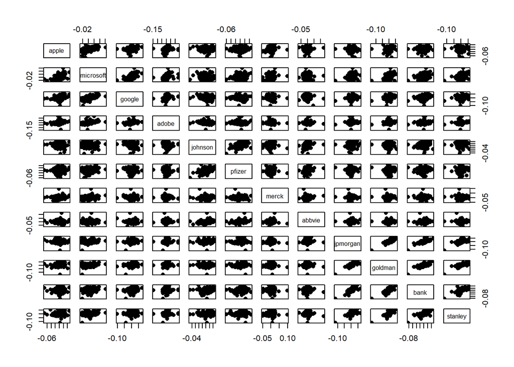

```r
df=data.frame(apple,microsoft,google,adobe,johnson,pfizer,merck,abbvie,jpmorgan,goldman,bank,stanley)
pairs(1-df,pch=16)
```

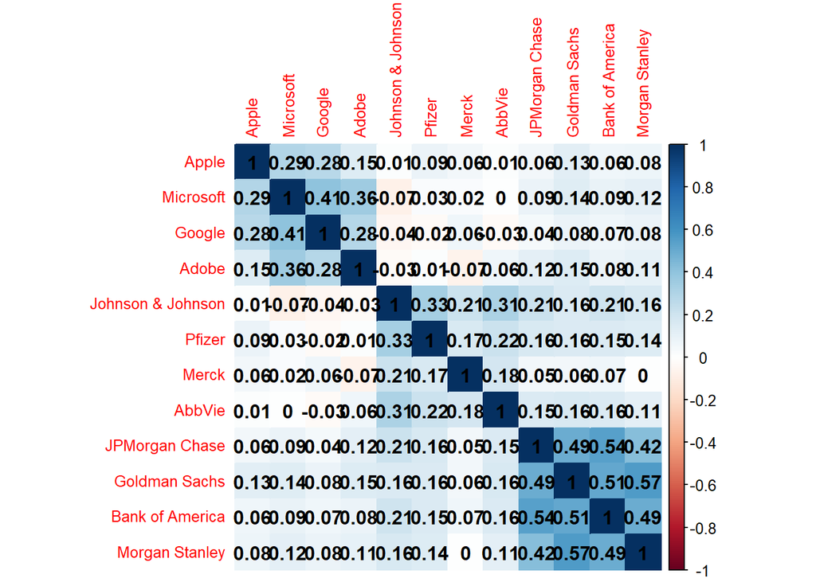

```r
cor_matrix=cor(df,method="kendall")
colnames(cor_matrix)=c("Apple","Microsoft","Google","Adobe","Johnson & Johnson","Pfizer","Merck","AbbVie","JPMorgan Chase","Goldman Sachs","Bank of America", "Morgan Stanley")
rownames(cor_matrix)=c("Apple","Microsoft","Google","Adobe","Johnson & Johnson","Pfizer","Merck","AbbVie","JPMorgan Chase","Goldman Sachs","Bank of America", "Morgan Stanley")
library(corrplot)
corrplot(cor_matrix, method="color", tl.cex=0.8, addCoef.col="black")
```

## Backtest

We apply the apply portfolio weights (Opt1–Opt5 and single-step) to the out-of-sample period Jan–Jun 2025. Returns are plotted as ‘losses’ (positive values) vs ‘gains’ (negative).

First we load the data.

```r
start_date <- "2025-01-01"
end_date <- "2025-06-13"



#################################################################################
##########################     Technology         ###############################
#################################################################################

#Apple
apple_df <- getSymbols('AAPL', src='yahoo', auto.assign=FALSE)
apple <- exp(as.numeric(diff(log(apple_df$AAPL.Close[start_date <= index(apple_df) & index(apple_df) <= end_date])))[-1])

apple_close <- Cl(apple_df)[paste0(start_date, "/", end_date)]
gross_returns <- apple_close[-1] / lag(apple_close, k = 1)[-1]

#Microsoft
microsoft_df <- getSymbols('MSFT', src='yahoo', auto.assign=FALSE)
microsoft <- exp(as.numeric(diff(log(microsoft_df$MSFT.Close[start_date <= index(microsoft_df) & index(microsoft_df) <= end_date])))[-1])

#Google
google_df <- getSymbols('GOOGL', src='yahoo', auto.assign=FALSE)
google <- exp(as.numeric(diff(log(google_df$GOOGL.Close[start_date <= index(google_df) & index(google_df) <= end_date])))[-1])

#Adobe
adobe_df <- getSymbols('ADBE', src='yahoo', auto.assign=FALSE)
adobe <- exp(as.numeric(diff(log(adobe_df$ADBE.Close[start_date <= index(adobe_df) & index(adobe_df) <= end_date])))[-1])



#################################################################################
##########################     Healthcare         ###############################
#################################################################################


#Johnson & Johnson
johnson_df <- getSymbols('JNJ', src='yahoo', auto.assign=FALSE)
johnson <- exp(as.numeric(diff(log(johnson_df$JNJ.Close[start_date <= index(johnson_df) & index(johnson_df) <= end_date])))[-1])

#Pfizer
pfizer_df <- getSymbols('PFE', src='yahoo', auto.assign=FALSE)
pfizer <- exp(as.numeric(diff(log(pfizer_df$PFE.Close[start_date <= index(pfizer_df) & index(pfizer_df) <= end_date])))[-1])

#Merck
merck_df <- getSymbols('MRK', src='yahoo', auto.assign=FALSE)
merck <- exp(as.numeric(diff(log(merck_df$MRK.Close[start_date <= index(merck_df) & index(merck_df) <= end_date])))[-1])

#abbvie
abbvie_df <- getSymbols('ABBV', src='yahoo', auto.assign=FALSE)
abbvie <- exp(as.numeric(diff(log(abbvie_df$ABBV.Close[start_date <= index(abbvie_df) & index(abbvie_df) <= end_date])))[-1])




#################################################################################
##################               Finance               ##########################
#################################################################################

#JPMorgan Chase
jpmorgan_df <- getSymbols('JPM', src='yahoo', auto.assign=FALSE)
jpmorgan<- exp(as.numeric(diff(log(jpmorgan_df$JPM.Close[start_date <= index(jpmorgan_df) & index(jpmorgan_df) <= end_date])))[-1])

#Goldman Sachs
goldman_df <- getSymbols('GS', src='yahoo', auto.assign=FALSE)
goldman <- exp(as.numeric(diff(log(goldman_df$GS.Close[start_date <= index(goldman_df) & index(goldman_df) <= end_date])))[-1])

#Bank of America
bank_df <- getSymbols('BAC', src='yahoo', auto.assign=FALSE)
bank <- exp(as.numeric(diff(log(bank_df$BAC.Close[start_date <= index(bank_df) & index(bank_df) <= end_date])))[-1])

#Morgan Stanley
stanley_df <- getSymbols('MS', src='yahoo', auto.assign=FALSE)
stanley <- exp(as.numeric(diff(log(stanley_df$MS.Close[start_date <= index(stanley_df) & index(stanley_df) <= end_date])))[-1])





df=data.frame(apple,microsoft,google,adobe,johnson,pfizer,merck,abbvie,jpmorgan,goldman,bank,stanley)

##Fill in appropriate weights
weightSingle=c(0.14,0.06,0.03,0.04,0.42,0,0.13,0.05,0.06,0,0,0.07)
weightOpt1=c(0.1540,0.1120,0.0056,0.0084,0.3540,0.0900,0.1260,0.0300,0.0216,0.0132,0.0672,0.0180)
weightOpt2=c(0.1155,0.0840,0.0042,0.0063,0.3481,0.0885,0.1239,0.0295,0.0360,0.0220,0.1120,0.0300)
weightOpt3=c(0.35,0,0,0,0,0,0.30,0,0,0,0.35,0)
weightOpt4=c(0.0525,0.0525,0.0525,0.0525,0.1475,0.1475,0.1475,0.1475,0.0500,0.0500,0.0500,0.0500)

cluster1=c(0.55,0.40,0.02,0.03)
cluster2=c(0.59,0.15,0.21,0.05)
cluster3=c(0.18,0.11,0.56,0.15)
weightOpt5=c(1/3*cluster1 ,1/3*cluster2, 1/3*cluster3)


returnsSingle=1-as.matrix(df)%*%matrix(weightSingle,nrow=12,ncol=1)
returns1=1-as.matrix(df)%*%matrix(weightOpt1,nrow=12,ncol=1)
returns2=1-as.matrix(df)%*%matrix(weightOpt2,nrow=12,ncol=1)
returns3=1-as.matrix(df)%*%matrix(weightOpt3,nrow=12,ncol=1)
returns4=1-as.matrix(df)%*%matrix(weightOpt4,nrow=12,ncol=1)
returns5=1-as.matrix(df)%*%matrix(weightOpt5,nrow=12,ncol=1)
```

We construct a Figure with performance of the different portfolios. Positive values are losses.

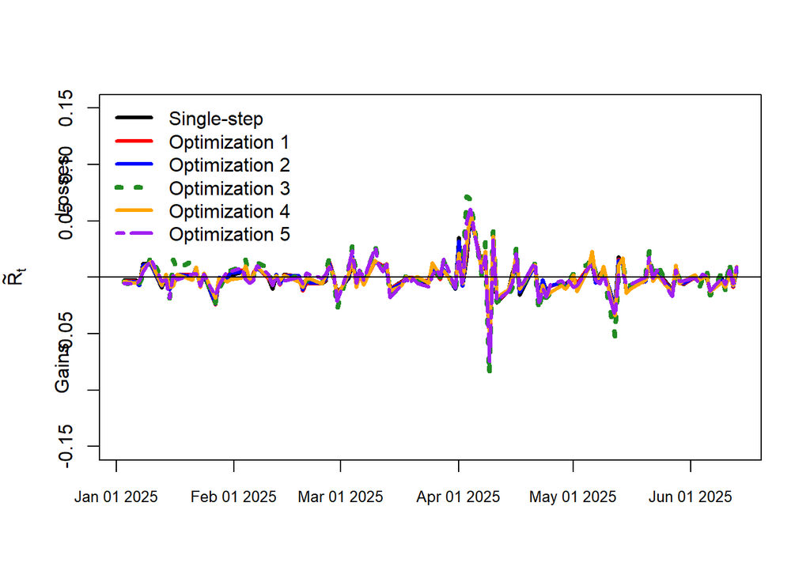

```r
par(mar = c(5.1, 4.3, 4.1, 2.1))
plot(index(gross_returns),returnsSingle,type="l",ylim=c(-0.15,0.15),lwd=3,xaxt="n",xlab="",ylab=TeX("$\\tilde{R}_t$"))
pretty_dates <- pretty(index(gross_returns))
axis(1, at = pretty_dates, labels = format(pretty_dates, "%b %d %Y"), cex.axis = 0.8)
ylims <- par("usr")[3:4]
xpos <- par("usr")[1] -10
# "Gains" (for negative values)
text(x = xpos, y = mean(c(ylims[1], 0)), labels = "Gains", srt = 90, adj = 0.5, xpd = TRUE)

# "Losses" (for positive values)
text(x = xpos,  y = mean(c(0, ylims[2])), labels = "Losses", srt = 90, adj = 0.5, xpd = TRUE)
lines(index(gross_returns),returns1,col="red",lwd=3)
lines(index(gross_returns),returns2,col="blue",lwd=3)
lines(index(gross_returns),returns3,col="forestgreen",lwd=4,lty=3)
lines(index(gross_returns),returns4,col="orange",lwd=3)
lines(index(gross_returns),returns5,col="purple",lwd=3,lty=6)
legend("topleft",col=c("black","red","blue","forestgreen","orange","purple"),
       legend=c("Single-step","Optimization 1","Optimization 2","Optimization 3","Optimization 4","Optimization 5"),
       lty=c(1,1,1,3,1,6),lwd=c(3,3,3,4,3,3),bty="n")
abline(h=0)
```

```r
par(mar = c(5.1, 4.1, 4.1, 2.1))#default
```

Construction of Figure with performance of individual stocks. Stocks from the same cluster have the same color.

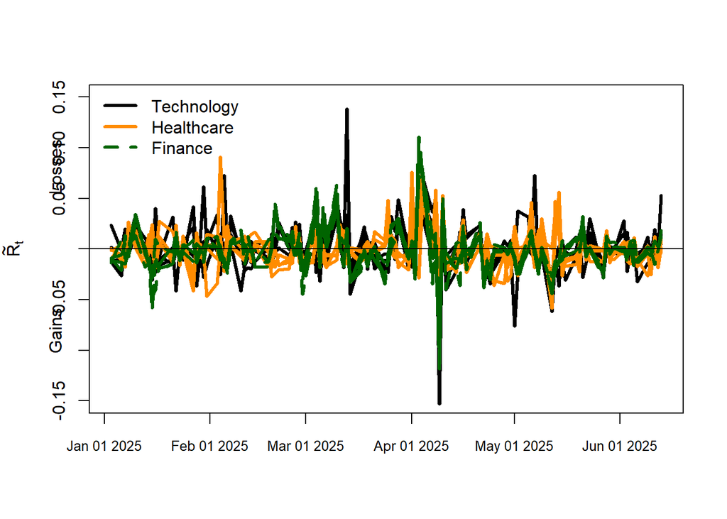

```r
par(mar = c(5.1, 4.3, 4.1, 2.1))
plot(index(gross_returns), 1-coredata(gross_returns), type = "l",
     ylim = c(-0.15, 0.15), lwd = 3, ylab = TeX("$\\tilde{R}_t$"), xlab = "", col = "black", xaxt = "n")
pretty_dates <- pretty(index(gross_returns))
axis(1, at = pretty_dates, labels = format(pretty_dates, "%b %d %Y"), cex.axis = 0.8)
ylims <- par("usr")[3:4]
xpos <- par("usr")[1] -10
# "Gains" (for negative values)
text(x = xpos, y = mean(c(ylims[1], 0)), labels = "Gains", srt = 90, adj = 0.5, xpd = TRUE)

# "Losses" (for positive values)
text(x = xpos,  y = mean(c(0, ylims[2])), labels = "Losses", srt = 90, adj = 0.5, xpd = TRUE)


lines(index(gross_returns),1-df[,2], col = "black",lwd=3)
lines(index(gross_returns),1-df[,3], col = "black",lwd=3)
lines(index(gross_returns),1-df[,4], col = "black",lwd=3)

lines(index(gross_returns),1-df[,5], col = "#FF8C00",lwd=3)
lines(index(gross_returns),1-df[,6], col = "#FF8C00",lwd=3)
lines(index(gross_returns),1-df[,7], col = "#FF8C00",lwd=3)
lines(index(gross_returns),1-df[,8], col = "#FF8C00",lwd=3)

lines(index(gross_returns),1-df[,9], col = "#006400",lwd=3,lty=5)
lines(index(gross_returns),1-df[,10], col = "#006400",lwd=3,lty=5)
lines(index(gross_returns),1-df[,11], col = "#006400",lwd=3,lty=5)
lines(index(gross_returns),1-df[,12], col = "#006400",lwd=3,lty=5)
legend("topleft",col=c("black","#FF8C00","#006400"),lwd=c(3,3,3),lty=c(1,1,2),legend=c("Technology","Healthcare","Finance"),bty="n")
abline(h=0)
```

```r
par(mar = c(5.1, 4.1, 4.1, 2.1))#default
```